# phyloseq_6_Gap Statistic

wentao

2019/8/23

# 聚类分析

**Gap Statistic**

### 这批数据究竟能聚类成几份呢？

**How many clusters are there?**

我们对数据进行分类，看看到底聚成多少的类别。 Gap统计值来确定k的个数，通过对数据进行bootstrap抽样来比较内差异性。这里使用cluster软件包里面的clusGap函数计算。

以下是phyloseq用于聚类的案例，并且将结果使用包装在phyloseq包中的ggplot展示。

> From the clusGap documentation: The clusGap function from the cluster package calculates a goodness of clustering measure, called the “gap” statistic. For each number of clusters k, it compares (W(k)) with E^*[(W(k))] where the latter is defined via bootstrapping, i.e. simulating from a reference distribution.

> The following is an example performing the gap statistic on ordination results calculated using phyloseq tools, followed by an example of how a ggplot-based wrapper for this example might be included in the phyloseq package.

载入包，查看版本信息

```r
library("phyloseq"); packageVersion("phyloseq")
```

```
## [1] '1.28.0'
```

```r
library("cluster"); packageVersion("cluster")
```

```
## [1] '2.1.0'
```

```r
library("ggplot2"); packageVersion("ggplot2")
```

```
## [1] '3.2.0'
```

### 导入绘图主题和数据

```r
theme_set(theme_bw())
# Load data
data(enterotype)
```

```r
# ordination
exord = ordinate(enterotype, method="MDS", distance="jsd")
```

### 聚类计算

Compute Gap Statistic

根据排序得分估计最优聚类 clusGap()函数一般我们用于来计算用于估计最优聚类k个数

```r
pam1 = function(x, k){list(cluster = pam(x,k, cluster.only=TRUE))}
x = phyloseq:::scores.pcoa(exord, display="sites")
# gskmn = clusGap(x[, 1:2], FUN=kmeans, nstart=20, K.max = 6, B = 500)
gskmn = clusGap(x[, 1:2], FUN=pam1, K.max = 6, B = 50)
gskmn
```

```
## Clustering Gap statistic ["clusGap"] from call:
## clusGap(x = x[, 1:2], FUNcluster = pam1, K.max = 6, B = 50)
## B=50 simulated reference sets, k = 1..6; spaceH0="scaledPCA"
##  --> Number of clusters (method 'firstSEmax', SE.factor=1): 4
##          logW   E.logW       gap     SE.sim
## [1,] 2.995599 3.115847 0.1202485 0.01998888
## [2,] 2.209852 2.769082 0.5592304 0.02062896
## [3,] 1.922188 2.584029 0.6618403 0.02645286
## [4,] 1.685798 2.416808 0.7310103 0.02758949
## [5,] 1.601025 2.282258 0.6812337 0.01846695
## [6,] 1.480640 2.180588 0.6999475 0.02553313
```

### 可视化K值

```r
library(factoextra)
```

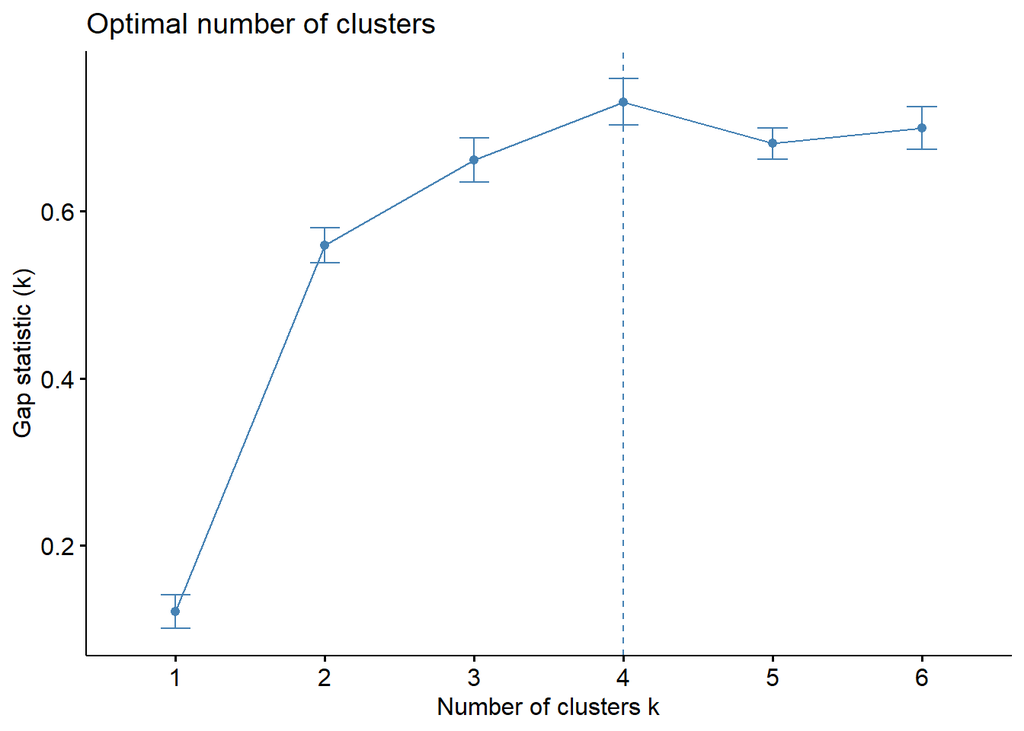

```r
library(cluster)
fviz_gap_stat(gskmn)
```

### 下面构造统计函数，方便运算，构造出图函数。

```r
gap_statistic_ordination = function(ord, FUNcluster, type="sites", K.max=6, axes=c(1:2), B=500, verbose=interactive(), ...){
    require("cluster")
    #   If "pam1" was chosen, use this internally defined call to pam
    if(FUNcluster == "pam1"){
        FUNcluster = function(x,k) list(cluster = pam(x, k, cluster.only=TRUE))
    }
    # Use the scores function to get the ordination coordinates
    x = phyloseq:::scores.pcoa(ord, display=type)
    #   If axes not explicitly defined (NULL), then use all of them
    if(is.null(axes)){axes = 1:ncol(x)}
    #   Finally, perform, and return, the gap statistic calculation using cluster::clusGap
    clusGap(x[, axes], FUN=FUNcluster, K.max=K.max, B=B, verbose=verbose, ...)
}



plot_clusgap = function(clusgap, title="Gap Statistic calculation results"){
    require("ggplot2")
    gstab = data.frame(clusgap$Tab, k=1:nrow(clusgap$Tab))
    p = ggplot(gstab, aes(k, gap)) + geom_line() + geom_point(size=5)
    p = p + geom_errorbar(aes(ymax=gap+SE.sim, ymin=gap-SE.sim))
    p = p + ggtitle(title)
    return(p)
}
```

计算

```r
gs = gap_statistic_ordination(exord, "pam1", B=50, verbose=FALSE)
print(gs, method="Tibs2001SEmax")
```

```
## Clustering Gap statistic ["clusGap"] from call:
## clusGap(x = x[, axes], FUNcluster = FUNcluster, K.max = K.max,     B = B, verbose = verbose)
## B=50 simulated reference sets, k = 1..6; spaceH0="scaledPCA"
##  --> Number of clusters (method 'Tibs2001SEmax', SE.factor=1): 4
##          logW   E.logW       gap     SE.sim
## [1,] 2.995599 3.112687 0.1170886 0.02084155
## [2,] 2.209852 2.765719 0.5558672 0.02225583
## [3,] 1.922188 2.583286 0.6610972 0.02499582
## [4,] 1.685798 2.407248 0.7214505 0.02734541
## [5,] 1.601025 2.276355 0.6753299 0.02213037
## [6,] 1.480640 2.180095 0.6994546 0.02371530
```

可视化结果

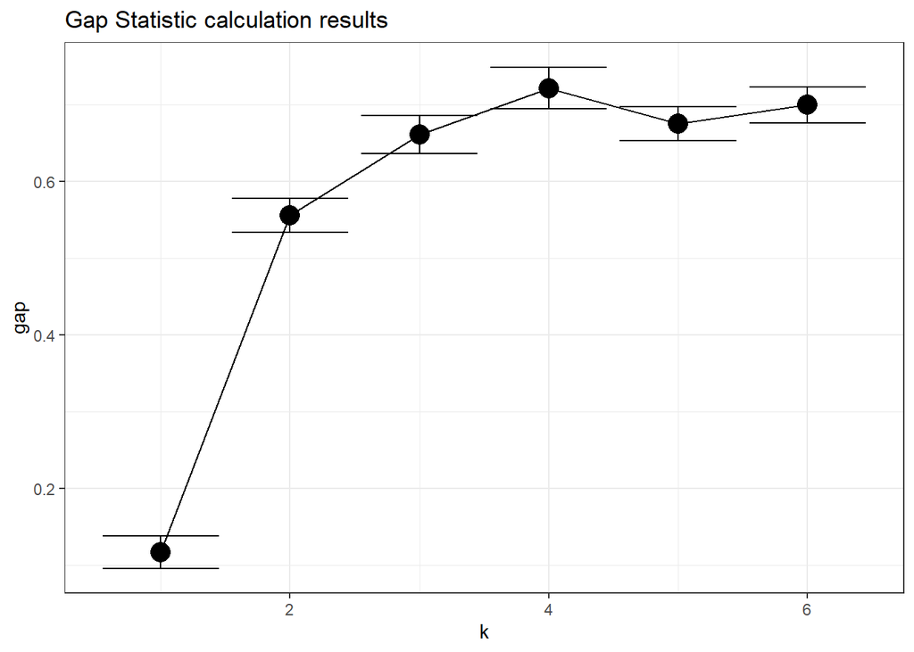

```r
plot_clusgap(gs)
```